# Prediction Assignment - PML

DanFV1

4/5/2022

# Background

Using devices such as *Jawbone Up*, *Nike FuelBand*, and *Fitbit* it is now possible to collect a large amount of data about personal activity relatively inexpensively. These type of devices are part of the quantified self movement – a group of enthusiasts who take measurements about themselves regularly to improve their health, to find patterns in their behavior, or because they are tech geeks. One thing that people regularly do is quantify *how much* of a particular activity they do, but they rarely quantify *how well they do it*.

# Goal

The goal is to use data from accelerometers on the belt, forearm, arm, and dumbell of 6 participants. They were asked to perform barbell lifts correctly and incorrectly in 5 different ways.The goal of this project is to predict the manner in which they did the exercise. This is the “class” variable in the training set, any of the other variables should be used to predict.

# Data

The training data for this project are available here:

https://d396qusza40orc.cloudfront.net/predmachlearn/pml-training.csv

The test data are available here:

https://d396qusza40orc.cloudfront.net/predmachlearn/pml-testing.csv

Credits:  
*Velloso, E.; Bulling, A.; Gellersen, H.; Ugulino, W.; Fuks, H. Qualitative Activity Recognition of Weight Lifting Exercises. Proceedings of 4th International Conference in Cooperation with SIGCHI (Augmented Human ’13) . Stuttgart, Germany: ACM SIGCHI, 2013.*

# Data Processing

## Libraries

```r
library(caret)
library(randomForest)
library(rpart)
library(rpart.plot)
library(rattle)
library(knitr)
library(lattice)
library(ggplot2)
library(Rcpp)
library(corrplot)

# Models
library(gbm)
library(randomForest)
```

## Load Data

```r
training <- read.csv("pml-training.csv", header=TRUE)
testing <- read.csv("pml-testing.csv", header=TRUE)
dim(training)
```

```
## [1] 19622   160
```

```r
dim(testing)
```

```
## [1]  20 160
```

## Cleaning Data

Removing Variables thar are mostly NA (>95%):

```r
na_variab <- sapply(training, function(x) mean(is.na(x))) > 0.95
training_set <- training[ , na_variab == FALSE]
testing_set <- testing[ , na_variab == FALSE]
dim(training_set)
```

```
## [1] 19622    93
```

```r
dim(testing_set)
```

```
## [1] 20 93
```

Removing Identification Variables:

```r
training_set <- training_set[ , -(1:5)]
testing_set <- testing_set[ , -(1:5)]
dim(training_set)
```

```
## [1] 19622    88
```

```r
dim(testing_set)
```

```
## [1] 20 88
```

Removing the Near Zero Variance Variables:

```r
nz_var_variab <- nearZeroVar(training_set)
training_set <- training_set[ , -nz_var_variab]
testing_set <- testing_set[ , -nz_var_variab]
dim(training_set)
```

```
## [1] 19622    54
```

```r
dim(testing_set)
```

```
## [1] 20 54
```

## Data Preparation

Randomly split the training data into training data and testing data, with 70/30 ratio.  
We will use the initial test data on the trained model to make predictions.

```r
set.seed(123)
in_train  <- createDataPartition(training_set$classe,
                                 p=0.70,
                                 list=FALSE)
train_set <- training_set[ in_train, ]
test_set  <- training_set[-in_train, ]
```

# Choosing a Model

Three methods will be applied to model the regressions (on the train_set) and the best one (with the highest accuracy when applied to the test_set) will be used for the quiz predictions.

## Decision Tree

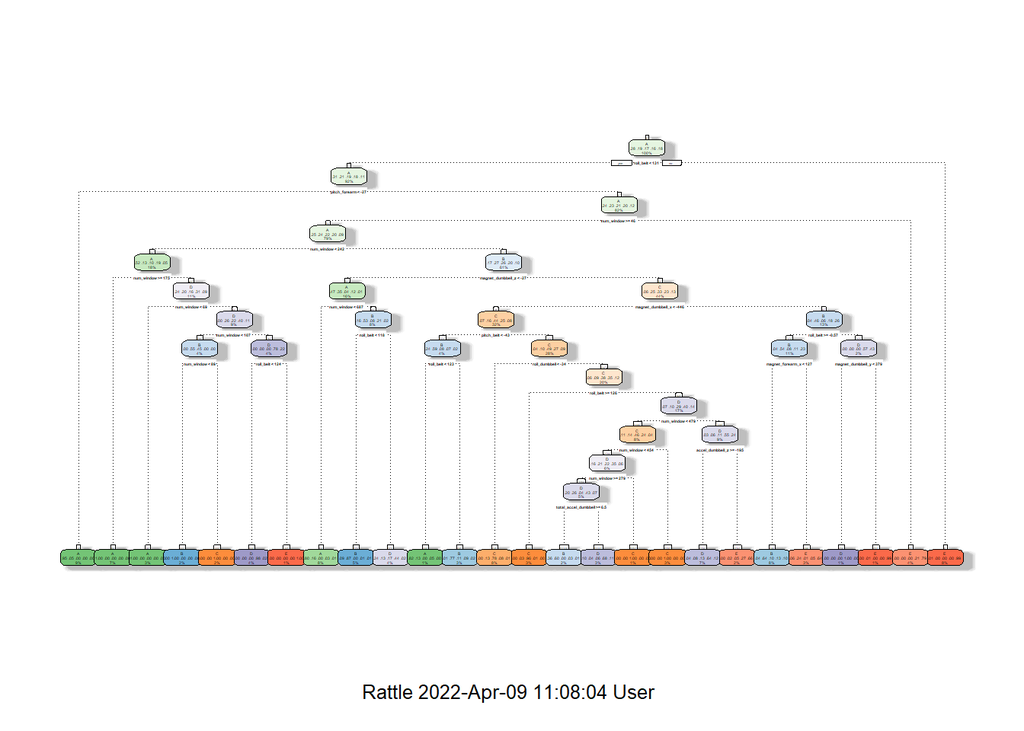

```r
decisiontree_fit <- rpart(classe ~ ., data = train_set, method="class")
fancyRpartPlot(decisiontree_fit)
```

Use the test_set to see how accurate the prediction is:

```r
predict_decisiontree <- predict(decisiontree_fit,
                                newdata = test_set,
                                type="class")
confmat_decisiontree <- confusionMatrix(table(predict_decisiontree,
                                 test_set$classe))
confmat_decisiontree
```

```
## Confusion Matrix and Statistics
##
##
## predict_decisiontree    A    B    C    D    E
##                    A 1459   86    0   13    2
##                    B  104  855   61   75   51
##                    C    0   57  856   37    3
##                    D   92   81   99  759   86
##                    E   19   60   10   80  940
##
## Overall Statistics
##
##                Accuracy : 0.8274
##                  95% CI : (0.8175, 0.8369)
##     No Information Rate : 0.2845
##     P-Value [Acc > NIR] : < 2.2e-16
##
##                   Kappa : 0.7823
##
##  Mcnemar's Test P-Value : NA
##
## Statistics by Class:
##
##                      Class: A Class: B Class: C Class: D Class: E
## Sensitivity            0.8716   0.7507   0.8343   0.7873   0.8688
## Specificity            0.9760   0.9387   0.9800   0.9273   0.9648
## Pos Pred Value         0.9353   0.7461   0.8982   0.6795   0.8476
## Neg Pred Value         0.9503   0.9401   0.9655   0.9570   0.9703
## Prevalence             0.2845   0.1935   0.1743   0.1638   0.1839
## Detection Rate         0.2479   0.1453   0.1455   0.1290   0.1597
## Detection Prevalence   0.2651   0.1947   0.1619   0.1898   0.1884
## Balanced Accuracy      0.9238   0.8447   0.9072   0.8573   0.9168
```

## GBM

```r
set.seed(123)
gbm_control <- trainControl(method = "repeatedcv",
                            number = 5,
                            repeats = 2)

gbm_fit  <- train(classe ~ .,
                  data=train_set,
                  method = "gbm",
                  trControl = gbm_control,
                  verbose = FALSE)
gbm_fit$finalModel
```

```
## A gradient boosted model with multinomial loss function.
## 150 iterations were performed.
## There were 53 predictors of which 53 had non-zero influence.
```

```r
print(gbm_fit)
```

```
## Stochastic Gradient Boosting
##
## 13737 samples
##    53 predictor
##     5 classes: 'A', 'B', 'C', 'D', 'E'
##
## No pre-processing
## Resampling: Cross-Validated (5 fold, repeated 2 times)
## Summary of sample sizes: 10990, 10990, 10988, 10990, 10990, 10989, ...
## Resampling results across tuning parameters:
##
##   interaction.depth  n.trees  Accuracy   Kappa
##   1                   50      0.7578081  0.6927508
##   1                  100      0.8303490  0.7852491
##   1                  150      0.8690770  0.8343072
##   2                   50      0.8832715  0.8521778
##   2                  100      0.9396159  0.9235865
##   2                  150      0.9632017  0.9534423
##   3                   50      0.9305525  0.9120895
##   3                  100      0.9707360  0.9629753
##   3                  150      0.9854409  0.9815831
##
## Tuning parameter 'shrinkage' was held constant at a value of 0.1
##
## Tuning parameter 'n.minobsinnode' was held constant at a value of 10
## Accuracy was used to select the optimal model using the largest value.
## The final values used for the model were n.trees = 150, interaction.depth =
##  3, shrinkage = 0.1 and n.minobsinnode = 10.
```

Use the test_set to see how accurate the prediction is:

```r
predict_gbm <- predict(gbm_fit,
                       newdata=test_set)


gbm_confmat <- confusionMatrix(factor(predict_gbm),
                               factor(test_set$classe))

gbm_confmat
```

```
## Confusion Matrix and Statistics
##
##           Reference
## Prediction    A    B    C    D    E
##          A 1673   11    0    1    2
##          B    1 1111   10    6    0
##          C    0   16 1014    6    6
##          D    0    1    2  951   11
##          E    0    0    0    0 1063
##
## Overall Statistics
##
##                Accuracy : 0.9876
##                  95% CI : (0.9844, 0.9903)
##     No Information Rate : 0.2845
##     P-Value [Acc > NIR] : < 2.2e-16
##
##                   Kappa : 0.9843
##
##  Mcnemar's Test P-Value : NA
##
## Statistics by Class:
##
##                      Class: A Class: B Class: C Class: D Class: E
## Sensitivity            0.9994   0.9754   0.9883   0.9865   0.9824
## Specificity            0.9967   0.9964   0.9942   0.9972   1.0000
## Pos Pred Value         0.9917   0.9849   0.9731   0.9855   1.0000
## Neg Pred Value         0.9998   0.9941   0.9975   0.9974   0.9961
## Prevalence             0.2845   0.1935   0.1743   0.1638   0.1839
## Detection Rate         0.2843   0.1888   0.1723   0.1616   0.1806
## Detection Prevalence   0.2867   0.1917   0.1771   0.1640   0.1806
## Balanced Accuracy      0.9980   0.9859   0.9913   0.9918   0.9912
```

## Random Forest

```r
set.seed(123)
randforest_control <- trainControl(method="cv",
                                   number=3,
                                   verboseIter=FALSE)

randforest_fit <- train(classe ~ .,
                        data=train_set,
                        method="rf",
                        trControl=randforest_control)

randforest_fit$finalModel
```

```
##
## Call:
##  randomForest(x = x, y = y, mtry = min(param$mtry, ncol(x)))
##                Type of random forest: classification
##                      Number of trees: 500
## No. of variables tried at each split: 27
##
##         OOB estimate of  error rate: 0.23%
## Confusion matrix:
##      A    B    C    D    E  class.error
## A 3904    1    0    0    1 0.0005120328
## B    6 2648    3    1    0 0.0037622272
## C    0    7 2388    1    0 0.0033388982
## D    0    0    7 2245    0 0.0031083481
## E    0    0    0    5 2520 0.0019801980
```

Use the test_set to see how accurate the prediction is:

```r
randforest_predict <- predict(randforest_fit,
                      newdata=test_set)

randforest_confmat <- confusionMatrix(factor(randforest_predict),
                                      factor(test_set$classe))

randforest_confmat
```

```
## Confusion Matrix and Statistics
##
##           Reference
## Prediction    A    B    C    D    E
##          A 1674    1    0    0    0
##          B    0 1135    2    0    0
##          C    0    3 1024    1    0
##          D    0    0    0  963    4
##          E    0    0    0    0 1078
##
## Overall Statistics
##
##                Accuracy : 0.9981
##                  95% CI : (0.9967, 0.9991)
##     No Information Rate : 0.2845
##     P-Value [Acc > NIR] : < 2.2e-16
##
##                   Kappa : 0.9976
##
##  Mcnemar's Test P-Value : NA
##
## Statistics by Class:
##
##                      Class: A Class: B Class: C Class: D Class: E
## Sensitivity            1.0000   0.9965   0.9981   0.9990   0.9963
## Specificity            0.9998   0.9996   0.9992   0.9992   1.0000
## Pos Pred Value         0.9994   0.9982   0.9961   0.9959   1.0000
## Neg Pred Value         1.0000   0.9992   0.9996   0.9998   0.9992
## Prevalence             0.2845   0.1935   0.1743   0.1638   0.1839
## Detection Rate         0.2845   0.1929   0.1740   0.1636   0.1832
## Detection Prevalence   0.2846   0.1932   0.1747   0.1643   0.1832
## Balanced Accuracy      0.9999   0.9980   0.9986   0.9991   0.9982
```

## Conclusion

When comparing the models above, it is clear that Random Forest is the one with the best results.

Applying Random Forest Model on the initial testing data, we get the following:

```r
prediction_testing <- predict(randforest_fit,
                              newdata=testing_set)

prediction_testing
```

```
##  [1] B A B A A E D B A A B C B A E E A B B B
## Levels: A B C D E
```